[O’Hara on GitHub](https://github.com/oharac)

# Assemble grouping traits and gapfill using MICE

Compiled on Fri Sep 10 16:29:33 2021 by ohara

```r
knitr::opts_chunk$set(echo = TRUE, message = FALSE, warning = FALSE)

library(oharac)
oharac::setup()
source(here('common_fxns.R'))
```

# 1 Summary

Gather processed traits data, dropping prior gapfills and keeping only data from FishBase/SeaLifeBase (vulnerability traits will be analyzed separately). Assemble into a dataframe. Identify missing rate, then apply Multiple Imputation by Chained Equations (MICE) approach.

# 2 Data

See individual trait scripts.

# 3 Methods

## 3.1 Gather traits

Read in each dataset based on FishBase/SeaLifeBase data:

- max length
- trophic level
- max fecundity
- generation/max age to maturity
- water column position (categorical)

Note: Adult mobility data is taken only from the Traits Vulnerability project so is excluded here.

### 3.1.1 Max length

Gather FB/SLB max length data, ungapfilled. These values are in centimeters.

```r
length_df <- read_csv(here('_data/traits_grouping/trait_length_cm.csv')) %>%
  filter(!is.na(length)) %>%
  filter(length > 0) %>%
  select(species, spec_code, length)

summary(length_df$length)
```

```
##    Min. 1st Qu.  Median    Mean 3rd Qu.    Max.
##    0.00    3.80    9.00   19.59   20.40 5000.00
```

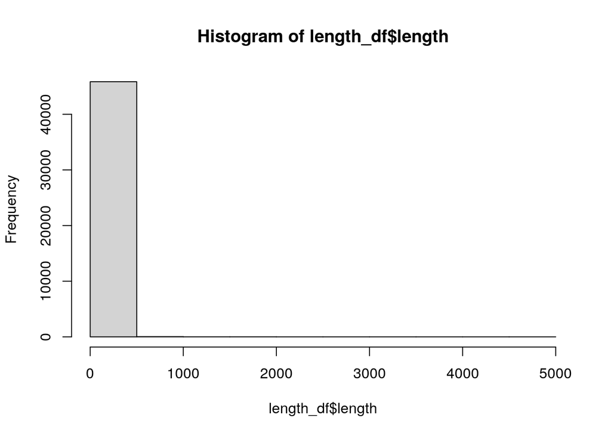

```r
hist(length_df$length)
```

```r
summary(log(length_df$length))
```

```
##    Min. 1st Qu.  Median    Mean 3rd Qu.    Max.
##  -8.016   1.335   2.197   2.055   3.016   8.517
```

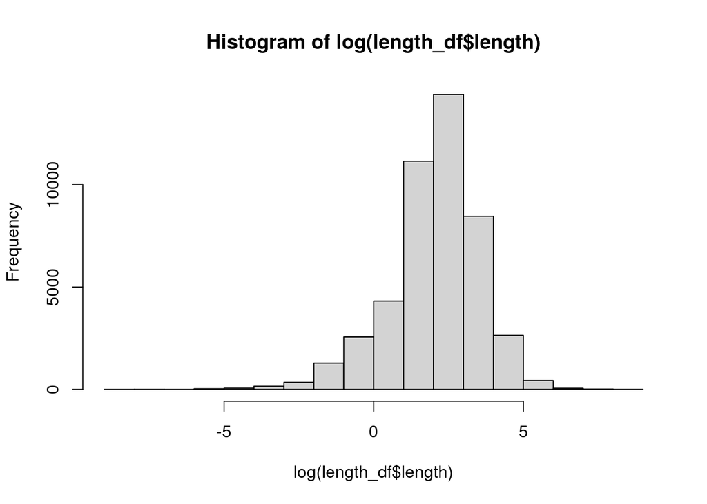

```r
hist(log(length_df$length))
```

Values appear to reasonably approach a log-normal distribution… we can transform prior to running MICE, and/or use Predictive mean matching (PMM).

### 3.1.2 Fecundity

```r
fecund_df <- read_csv(here('_data/traits_grouping/trait_reproduction.csv')) %>%
  filter(trait == 'fec') %>%
  filter(source == 'fb') %>%
  filter(gf_level == 1) %>% ### inclusive of sealifebase
  select(species, fecund = val_num) %>%
  filter(!is.na(fecund))

summary(fecund_df$fecund)
```

```
##      Min.   1st Qu.    Median      Mean   3rd Qu.      Max.
##         2      2756     55000   3208503    398125 873775333
```

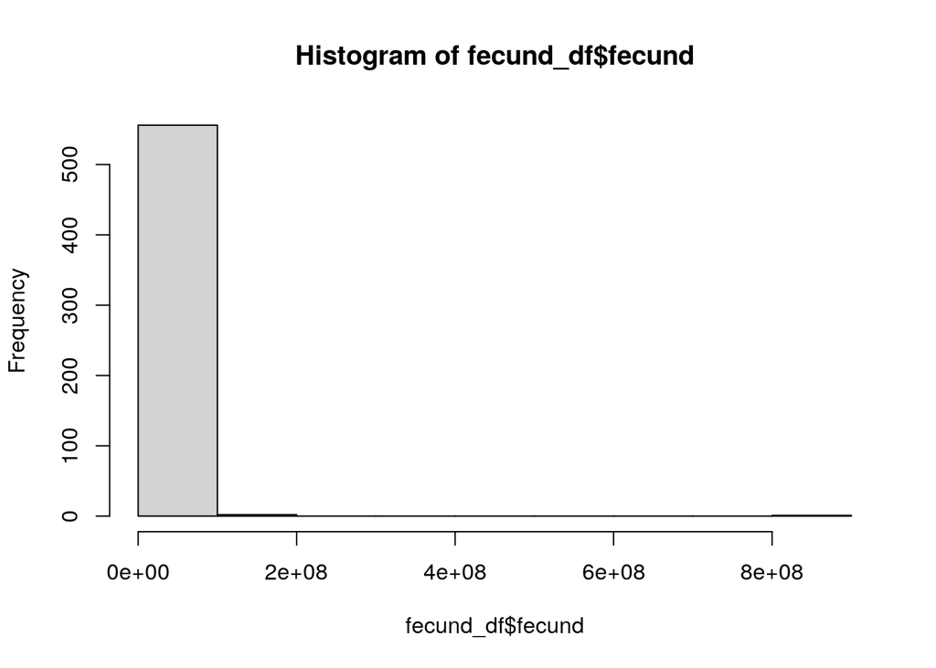

```r
hist(fecund_df$fecund)
```

```r
summary(log(fecund_df$fecund))
```

```
##    Min. 1st Qu.  Median    Mean 3rd Qu.    Max.
##  0.6931  7.9215 10.9151 10.2828 12.8944 20.5883
```

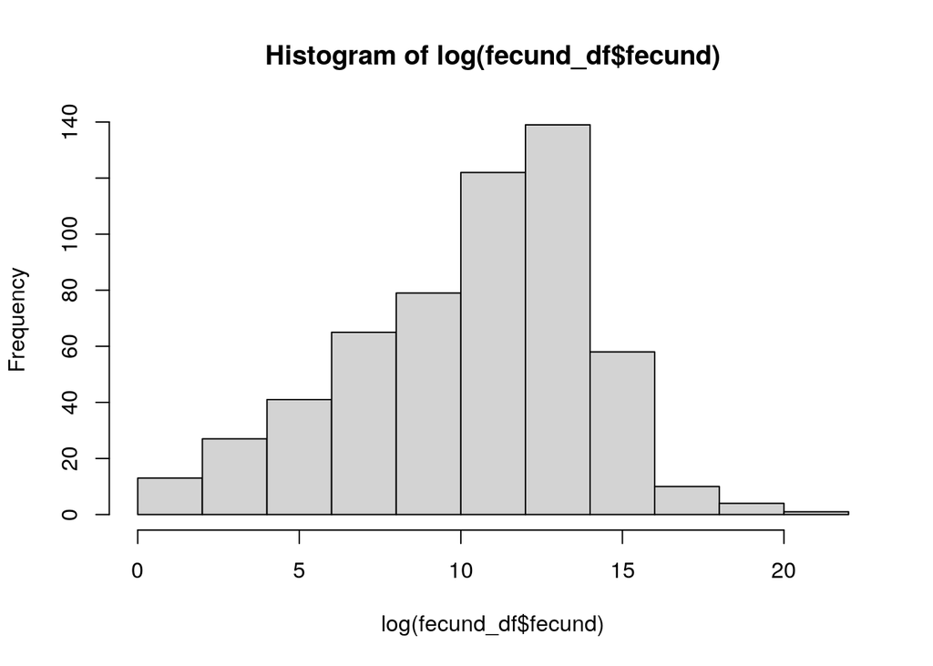

```r
hist(log(fecund_df$fecund))
```

### 3.1.3 Generation time

```r
gen_time_df <- read_csv(here('_data/traits_grouping/trait_reproduction.csv')) %>%
  filter(trait == 'age_mat') %>%
  filter(source == 'fb') %>%
  filter(gf_level == 1) %>% ### inclusive of sealifebase
  select(species, age_mat = val_num) %>%
  filter(!is.na(age_mat))

summary(gen_time_df$age_mat)
```

```
##     Min.  1st Qu.   Median     Mean  3rd Qu.     Max.
##  0.00396  1.44710  2.58727  3.45695  4.15576 36.20000
```

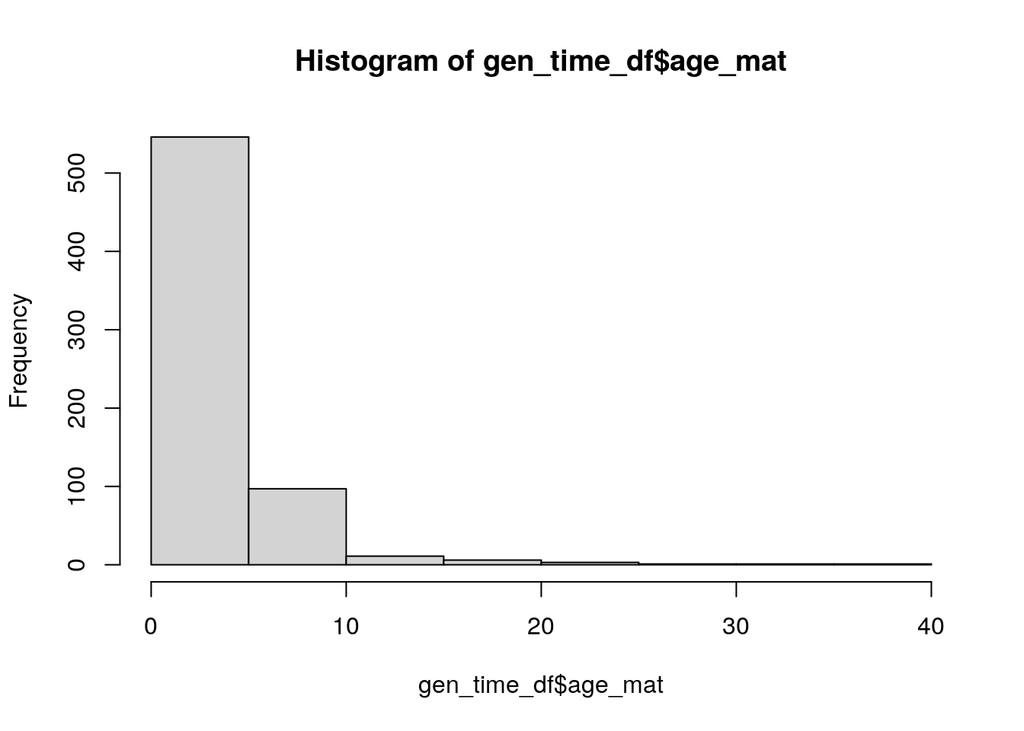

```r
hist(gen_time_df$age_mat)
```

```r
summary(log(gen_time_df$age_mat))
```

```
##    Min. 1st Qu.  Median    Mean 3rd Qu.    Max.
## -5.5303  0.3696  0.9506  0.8922  1.4245  3.5891
```

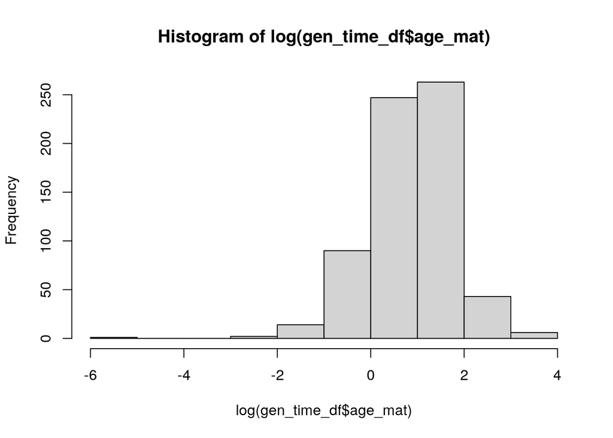

```r
hist(log(gen_time_df$age_mat))
```

### 3.1.4 water column position traits

Since values from FB/SLB are categorical variables, let’s include the categorical values from the traits-vulnerability project here as well. They may provide additional data for imputing other missing variables.

```r
water_col_traits_raw <- read_csv(here('_data/traits_grouping/trait_water_col_position.csv'))

water_col_traits_raw$source %>% table()
```

```
## .
##    fishbase     gapfill vuln_traits
##      102616       67951        8288
```

```r
   # fishbase     gapfill vuln_traits
   #   102616       67951        8288

trait_val_codes <- c(reef    = 'rf',
                     pelagic = 'pel',
                     benthic = 'ben',
                     benthopelagic = 'bp')

water_col_df <- water_col_traits_raw %>%
  filter(source != 'gapfill') %>%
  mutate(wcol = trait_val_codes[value],
         wcol = factor(wcol, levels = trait_val_codes, ordered = FALSE)) %>%
  select(species, wcol) %>%
  distinct()

table(water_col_df$wcol) %>% knitr::kable()
```

| Var1 | Freq |
| --- | --- |
| rf | 13528 |
| pel | 7739 |
| ben | 76126 |
| bp | 13511 |

### 3.1.5 Trophic level

```r
troph_df <- read_csv(here('_data/traits_grouping/trait_trophic_level.csv')) %>%
  filter(gf_level == 1) %>%
  select(# spec_code,
         species, troph = value) %>%
  filter(!is.na(troph) & troph > 0)

summary(troph_df$troph)
```

```
##    Min. 1st Qu.  Median    Mean 3rd Qu.    Max.
##   1.000   3.061   3.470   3.382   3.900   5.000
```

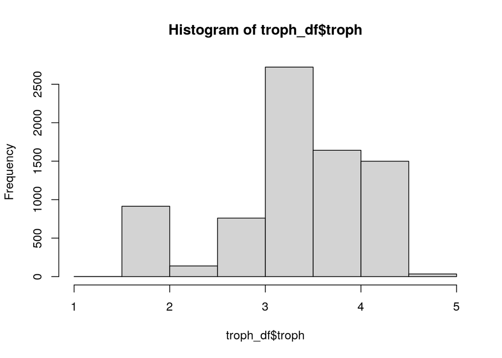

```r
hist(troph_df$troph)
```

```r
summary(log(troph_df$troph))
```

```
##    Min. 1st Qu.  Median    Mean 3rd Qu.    Max.
##   0.000   1.119   1.244   1.194   1.361   1.609
```

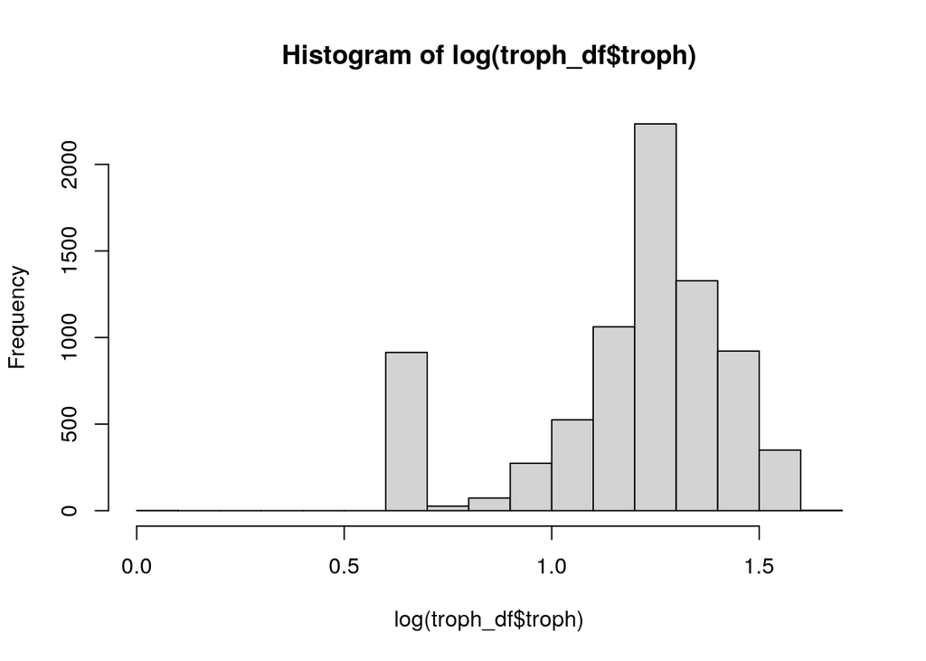

```r
hist(log(troph_df$troph))
```

## 3.2 Assemble and identify missingness

```r
traits_df_all <- length_df %>%
  full_join(fecund_df) %>%
  full_join(gen_time_df) %>%
  full_join(troph_df) %>%
  full_join(water_col_df)

### this will have at least one variable as not NA for each species...

missingness <- traits_df_all %>%
  summarize(missing_length  = sum(is.na(length))  / n(),
            missing_fecund  = sum(is.na(fecund))  / n(),
            missing_age_mat = sum(is.na(age_mat)) / n(),
            missing_troph   = sum(is.na(troph))   / n(),
            missing_wcol    = sum(is.na(wcol))    / n())

knitr::kable(missingness)
```

| missing_length | missing_fecund | missing_age_mat | missing_troph | missing_wcol |
| --- | --- | --- | --- | --- |
| 0.5886926 | 0.994958 | 0.9939997 | 0.93028 | 0.0020509 |

Based on this quick assessment, we are woefully inadequate on fecundity (only 559 spp), age to maturity (666 spp), and trophic level (7711 spp).

- Can additional values be filled using traits from other FishBase/SeaLifeBase tables?
- Since our goal is rough binning of values to inform FEs, we can probably get away with using vulnerability traits to fill gaps in fecundity and maturity since those have a relatively high number of bins…
- We may need other methods to fill trophic level. Perhaps genus-level imputation can fill some gaps here? Try a cross validation of this to check assumptions…